# PPOL670 - Assignment04

Author

Ming Zhou & Huixin Cai

Data source: https://data.virginia.gov/api/views/p2ww-25u5/rows.csv?accessType=DOWNLOAD

Github: https://github.com/Haarriga/assignment04

## Graph 1

Line chart： Virginia’s labor force and total population over years

```r
library(readr)
library(tidyverse)
data <- read_csv("Virginia_Employment_Status_of_the_Population_by_Sex_by_Race_and_by_Age_by_Year.csv")
```

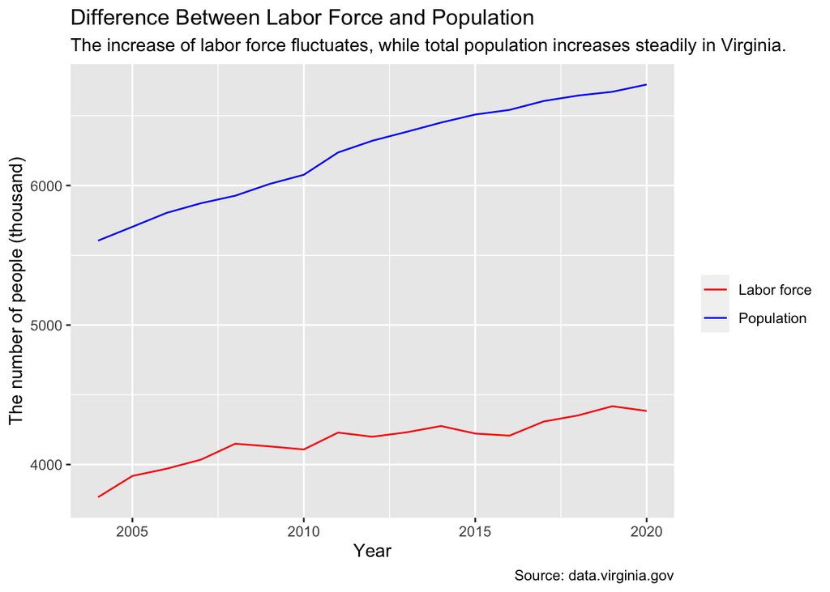

```r
data %>%
  filter(PopulationGroup == "Total") %>%
  ggplot() +
  geom_line(aes(x = Year,
                y = CivilianLaborForce,
                color = "Labor force")) +
  geom_line(aes(x = Year,
                y = CivilianNonInstitutionalPopulation,
                color = "Population")) +
  scale_color_manual("",
                     values = c(
    "Labor force" = "red",
    "Population" = "blue")) +
  labs(y = "The number of people (thousand)",
       title = "Difference Between Labor Force and Population",
       subtitle = "The increase of labor force fluctuates, while total population increases steadily in Virginia.",
       caption = "Source: data.virginia.gov")
```

In contrast to common sense, the labor force in Virginia has not grown as steadily as population in recent years. It even shrinks from time to time. The most recent shrinkage of labor force was in 2020, probably due to the covid-19 pandemic.

## Graph 2

Line chart: Virginia’s unemployment rate over years

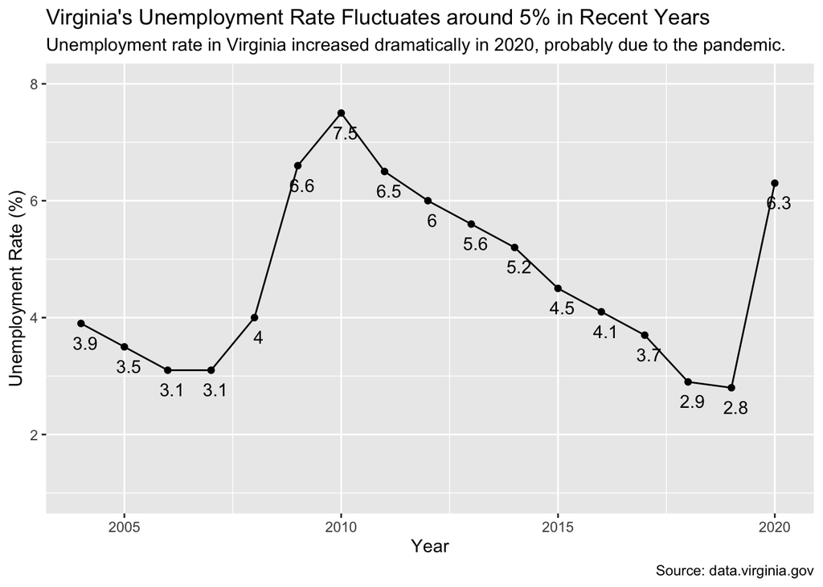

```r
data %>%
  filter(GroupCode == "01") %>%
  ggplot(aes(x = Year,
             y = CivilianLaborForceUnemployedPercentOfPopulation)) +
  geom_text(aes(label = CivilianLaborForceUnemployedPercentOfPopulation),
            vjust = 2,
            nudge_x = 0.1) +
  geom_line() +
  geom_point() +
  scale_y_continuous(limits = c(1,8)) +
labs(title = "Virginia's Unemployment Rate Fluctuates around 5% in Recent Years",
     subtitle = "Unemployment rate in Virginia increased dramatically in 2020, probably due to the pandemic.",
       caption = "Source: data.virginia.gov",
       x = "Year",
       y = "Unemployment Rate (%)")
```

In total, Virginia’s unemployment rate holds around 5% in recent years. Unemployment rate increased dramatically in 2008 and 2020, respectively due to the great recession and the covid-19 pandemic. In spite of the fluctuations, unemployment rate in Virginia has normally been lower than national unemployment rate in the US.

## Graph 3

Bar chart: Virginia’s unemployment rate by race

[figure not shown]

```r
data %>%
  filter(PopulationGroup == "Asian" | PopulationGroup == "Black or African American" |
           PopulationGroup == "White" |
           PopulationGroup == "Hispanic or Latino ethnicity") %>%
  filter(Year >= 2016) %>%
  ggplot() +
  geom_col(aes(x = Year,
               y = CivilianLaborForceUnemployedPercentOfPopulation,
               fill = PopulationGroup),
           position = "dodge") +
  scale_fill_manual(values = c("blue","light blue","purple","pink")) +
  labs(y = "Unemployment rate (%)",
       title = "Unemployment Rate among African American Is Normally the Highest",
       subtitle = "Unemployment rate among minority groups has been higher than among white people in the past 5 years in Virginia.",
       caption = "Source: data.virginia.gov")
```

## Graph 4

Pie chart: Virginia’s labor force by gender

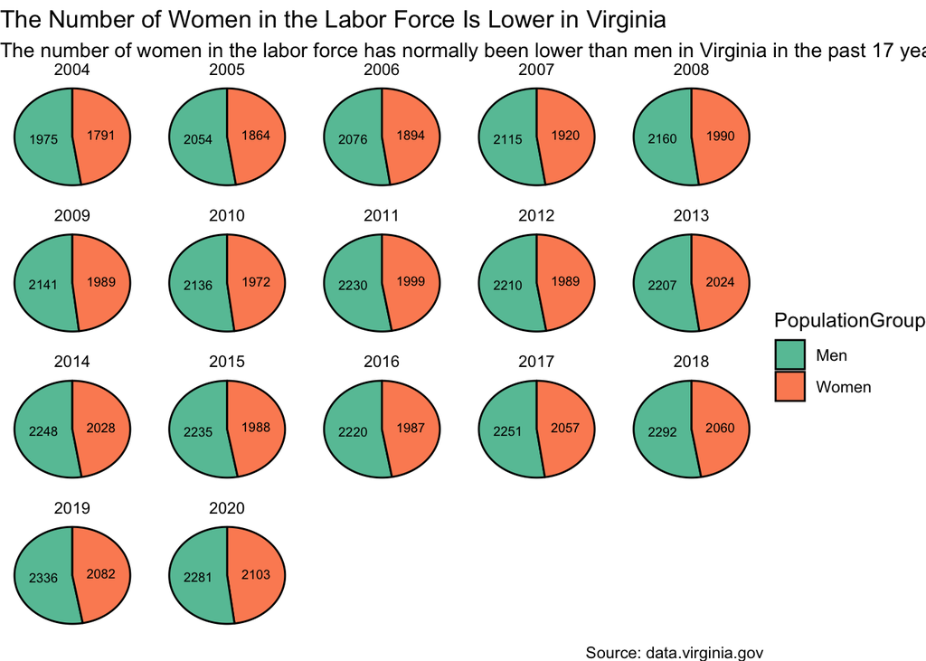

```r
cp <- coord_polar(theta = "y")
cp$is_free <- function() TRUE

data %>%
  filter(PopulationGroup == "Men"|
           PopulationGroup == "Women") %>%
  ggplot(aes(x = "",
             y = CivilianLaborForce,
             fill = PopulationGroup)) +
  geom_bar(stat = "identity",
           color = "black",
           width = 1) +
  geom_text(aes(label=CivilianLaborForce),
            position = position_stack(vjust = 0.5),
            size = 2.5) +
  cp +
  scale_fill_brewer(palette="Set2") +
  facet_wrap(~Year, scales = "free") +
  theme_void() +
  labs(title = "The Number of Women in the Labor Force Is Lower in Virginia",
       subtitle = "The number of women in the labor force has normally been lower than men in Virginia in the past 17 years.",
       caption = "Source: data.virginia.gov")
```

Overall, the number of women in the labor force was lower than men’s in Virginal in recent 17 years (2004-2020). The percentage of women in the workforce was stable over 17 years, with women accounting for approximately 48% of the workforce in Virginia. Accounting for the fact the percentage of the female population is higher than men, policies should incentivize women’s participation in the labor force to stimulate the increase rate of the labor force, as shown in graph 1.